[figure not shown]

# Addmision predict

This is a comprehensive data analysis and machine learning project focused on predicting the likelihood of admission to an educational institution based on various input features. This project entails thorough data exploration, preprocessing, and visualization to gain insights into the dataset's characteristics. It involves the creation and evaluation of predictive models to understand the factors that influence admission outcomes.

### 1. import the important libraries

```python
import numpy as np  # Library for numerical computations
import pandas as pd  # Library for data manipulation and analysis
import seaborn as sns  # Library for statistical data visualization
import matplotlib.pyplot as plt  # Library for creating plots and visualizations
```

```python
# Import the necessary Plotly libraries
import plotly.graph_objects as go  # Low-level interface for creating Plotly plots
import plotly.express as px  # Higher-level interface for creating interactive plots
```

```python
# Import the necessary ipywidgets libraries
import ipywidgets as widgets  # Library for creating interactive widgets
from ipywidgets import interact, interact_manual  # Functions for creating interactive controls
```

### 2. load the dataset

```python
addmision_df = pd.read_csv(r"C:\Users\User\Desktop\GitHub-projects\projects\Data-Dives-Projects-Unleashed\dataSets\course 1\week 2\datasets\Admission_Predict.csv")
addmision_df
addmision_df.drop('Serial No.', inplace=True, axis = 1)
```

### 3. Check the shape of the dataset to get the number of rows and columns.

```python
addmision_df.shape
```

```
(400, 8)
```

```python
addmision_df.size
```

```
3200
```

### 4. Display the first few rows of the dataset

```python
addmision_df.head()
```

|  | GRE Score | TOEFL Score | University Rating | SOP | LOR | CGPA | Research | Chance of Admit |
| --- | --- | --- | --- | --- | --- | --- | --- | --- |
| 0 | 337 | 118 | 4 | 4.5 | 4.5 | 9.65 | 1 | 0.92 |
| 1 | 324 | 107 | 4 | 4.0 | 4.5 | 8.87 | 1 | 0.76 |
| 2 | 316 | 104 | 3 | 3.0 | 3.5 | 8.00 | 1 | 0.72 |
| 3 | 322 | 110 | 3 | 3.5 | 2.5 | 8.67 | 1 | 0.80 |
| 4 | 314 | 103 | 2 | 2.0 | 3.0 | 8.21 | 0 | 0.65 |

```python
addmision_df.tail()
```

|  | GRE Score | TOEFL Score | University Rating | SOP | LOR | CGPA | Research | Chance of Admit |
| --- | --- | --- | --- | --- | --- | --- | --- | --- |
| 395 | 324 | 110 | 3 | 3.5 | 3.5 | 9.04 | 1 | 0.82 |
| 396 | 325 | 107 | 3 | 3.0 | 3.5 | 9.11 | 1 | 0.84 |
| 397 | 330 | 116 | 4 | 5.0 | 4.5 | 9.45 | 1 | 0.91 |
| 398 | 312 | 103 | 3 | 3.5 | 4.0 | 8.78 | 0 | 0.67 |
| 399 | 333 | 117 | 4 | 5.0 | 4.0 | 9.66 | 1 | 0.95 |

### 5. check the data types of each column and save them

```python
addmision_df.dtypes
```

```
GRE Score              int64
TOEFL Score            int64
University Rating      int64
SOP                  float64
LOR                  float64
CGPA                 float64
Research               int64
Chance of Admit      float64
dtype: object
```

### 6. Identify any missing values in the dataset

```python
len(addmision_df) - len(addmision_df.dropna())
```

```
0
```

```python
addmision_df.info()
```

```
<class 'pandas.core.frame.DataFrame'>
RangeIndex: 400 entries, 0 to 399
Data columns (total 8 columns):
 #   Column             Non-Null Count  Dtype
---  ------             --------------  -----
 0   GRE Score          400 non-null    int64
 1   TOEFL Score        400 non-null    int64
 2   University Rating  400 non-null    int64
 3   SOP                400 non-null    float64
 4   LOR                400 non-null    float64
 5   CGPA               400 non-null    float64
 6   Research           400 non-null    int64
 7   Chance of Admit    400 non-null    float64
dtypes: float64(4), int64(4)
memory usage: 25.1 KB
```

```python
addmision_df.describe()
```

|  | GRE Score | TOEFL Score | University Rating | SOP | LOR | CGPA | Research | Chance of Admit |
| --- | --- | --- | --- | --- | --- | --- | --- | --- |
| count | 400.000000 | 400.000000 | 400.000000 | 400.000000 | 400.000000 | 400.000000 | 400.000000 | 400.000000 |
| mean | 316.807500 | 107.410000 | 3.087500 | 3.400000 | 3.452500 | 8.598925 | 0.547500 | 0.724350 |
| std | 11.473646 | 6.069514 | 1.143728 | 1.006869 | 0.898478 | 0.596317 | 0.498362 | 0.142609 |
| min | 290.000000 | 92.000000 | 1.000000 | 1.000000 | 1.000000 | 6.800000 | 0.000000 | 0.340000 |
| 25% | 308.000000 | 103.000000 | 2.000000 | 2.500000 | 3.000000 | 8.170000 | 0.000000 | 0.640000 |
| 50% | 317.000000 | 107.000000 | 3.000000 | 3.500000 | 3.500000 | 8.610000 | 1.000000 | 0.730000 |
| 75% | 325.000000 | 112.000000 | 4.000000 | 4.000000 | 4.000000 | 9.062500 | 1.000000 | 0.830000 |
| max | 340.000000 | 120.000000 | 5.000000 | 5.000000 | 5.000000 | 9.920000 | 1.000000 | 0.970000 |

### 8. Rename columns

```python
addmision_df = addmision_df.rename(columns = {"SOP": 'Statement of Purpose', 'LOR ' : 'Letter of Recommendation' , 'Chance of Admit ':'Chance of Admit'})
addmision_df
```

|  | GRE Score | TOEFL Score | University Rating | Statement of Purpose | Letter of Recommendation | CGPA | Research | Chance of Admit |
| --- | --- | --- | --- | --- | --- | --- | --- | --- |
| 0 | 337 | 118 | 4 | 4.5 | 4.5 | 9.65 | 1 | 0.92 |
| 1 | 324 | 107 | 4 | 4.0 | 4.5 | 8.87 | 1 | 0.76 |
| 2 | 316 | 104 | 3 | 3.0 | 3.5 | 8.00 | 1 | 0.72 |
| 3 | 322 | 110 | 3 | 3.5 | 2.5 | 8.67 | 1 | 0.80 |
| 4 | 314 | 103 | 2 | 2.0 | 3.0 | 8.21 | 0 | 0.65 |
| ... | ... | ... | ... | ... | ... | ... | ... | ... |
| 395 | 324 | 110 | 3 | 3.5 | 3.5 | 9.04 | 1 | 0.82 |
| 396 | 325 | 107 | 3 | 3.0 | 3.5 | 9.11 | 1 | 0.84 |
| 397 | 330 | 116 | 4 | 5.0 | 4.5 | 9.45 | 1 | 0.91 |
| 398 | 312 | 103 | 3 | 3.5 | 4.0 | 8.78 | 0 | 0.67 |
| 399 | 333 | 117 | 4 | 5.0 | 4.0 | 9.66 | 1 | 0.95 |

400 rows × 8 columns

```python
addmision_df.to_csv('Admission_Predict_cleaned.csv', index=False)
```

### 9. Visualize the distribution of the target variable (Chance of Admit) using a histogram

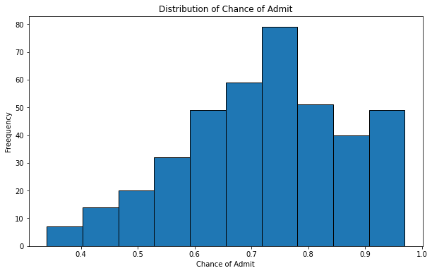

```python
plt.figure(figsize=(10,6))
plt.hist(addmision_df["Chance of Admit"], edgecolor='black')
plt.xlabel("Chance of Admit")
plt.ylabel("Freequency")
plt.title('Distribution of Chance of Admit')
plt.show()
```

### 10. Visualize the distribution of all the variables

```python
import plotly.graph_objects as go
import seaborn as sns
import matplotlib.pyplot as plt
import numpy as np
from ipywidgets import interact



# Create an interactive function to plot the histogram
@interact
def plot_histogram(column=addmision_df.columns.tolist()):
    # Create a Figure object
    fig = go.Figure()

    # Plot the histogram using Plotly with a beautiful color palette
    fig.add_trace(go.Histogram(x=addmision_df[column], marker=dict(color='turquoise')))

    # Update layout
    fig.update_layout(
        title=f"Distribution of {column} in Admission Data",
        xaxis_title=column,
        yaxis_title="Frequency",
        bargap=0.1,
        bargroupgap=0.2,
        template="plotly_dark"  # Using a dark template for an appealing look
    )

    # Show the figure
    fig.show()

    # Plot the histogram using Seaborn with varying shades of blue based on bar lengths
    plt.figure(figsize=(8, 6))
    ax = sns.histplot(data=addmision_df, x=column, kde=True)

    # Get the maximum height of the bars
    max_height = ax.get_ylim()[1]

    # Define the color map
    colormap = plt.cm.get_cmap('Blues')

    # Customize the colors based on bar lengths
    for bar in ax.patches:
        height = bar.get_height()
        ratio = height / max_height
        color = colormap(ratio)
        bar.set_color(color)

    plt.title(f"Distribution of {column} in Admission Data")
    plt.xlabel(column)
    plt.ylabel("Frequency")
    plt.grid(True)
    plt.show()
```

**Note:** I've launched the visualization on a cloud server, enabling you to engage with it directly through the web.

```python
from IPython.display import IFrame

# URL of the web page you want to display
web_page_url = "https://visualize-the-distribution-of-all-the.onrender.com"

# Display the web page using an iframe
IFrame(src=web_page_url, width="100%", height="500px")
```

[interactive chart not shown]

### 11. Explore the relationship between numerical features and the target variable

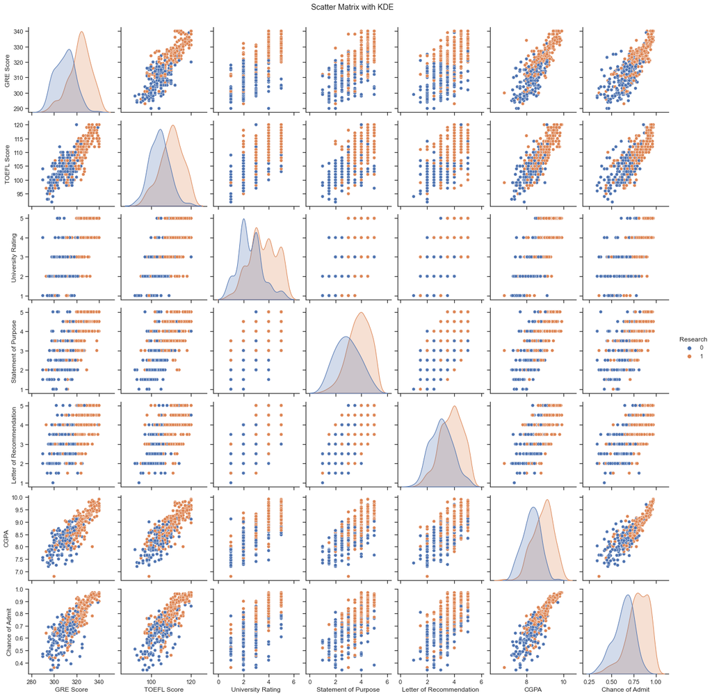

```python
import seaborn as sns
import matplotlib.pyplot as plt

# Create the scatter matrix with KDE plots
sns.set(style="ticks")
scatter_matrix = sns.pairplot(addmision_df, diag_kind="kde", markers="o", height=2.5, hue="Research")

# Customize the scatter matrix
scatter_matrix.fig.suptitle("Scatter Matrix with KDE", y=1.02)

plt.show()
```

### 12. Explore the correlation between features using a correlation matrix or heatmap.

```python
addmision_df.corr()
```

|  | GRE Score | TOEFL Score | University Rating | Statement of Purpose | Letter of Recommendation | CGPA | Research | Chance of Admit |
| --- | --- | --- | --- | --- | --- | --- | --- | --- |
| GRE Score | 1.000000 | 0.835977 | 0.668976 | 0.612831 | 0.557555 | 0.833060 | 0.580391 | 0.802610 |
| TOEFL Score | 0.835977 | 1.000000 | 0.695590 | 0.657981 | 0.567721 | 0.828417 | 0.489858 | 0.791594 |
| University Rating | 0.668976 | 0.695590 | 1.000000 | 0.734523 | 0.660123 | 0.746479 | 0.447783 | 0.711250 |
| Statement of Purpose | 0.612831 | 0.657981 | 0.734523 | 1.000000 | 0.729593 | 0.718144 | 0.444029 | 0.675732 |
| Letter of Recommendation | 0.557555 | 0.567721 | 0.660123 | 0.729593 | 1.000000 | 0.670211 | 0.396859 | 0.669889 |
| CGPA | 0.833060 | 0.828417 | 0.746479 | 0.718144 | 0.670211 | 1.000000 | 0.521654 | 0.873289 |
| Research | 0.580391 | 0.489858 | 0.447783 | 0.444029 | 0.396859 | 0.521654 | 1.000000 | 0.553202 |
| Chance of Admit | 0.802610 | 0.791594 | 0.711250 | 0.675732 | 0.669889 | 0.873289 | 0.553202 | 1.000000 |

let's visualize them:

```python
import plotly.graph_objects as go
import pandas as pd

# Calculate the correlation matrix
correlation_matrix = addmision_df.corr()

# Get the column names
columns = correlation_matrix.columns

# Create a hovertext for the correlation matrix
hovertext = [["<b>Correlation:</b> {:.2f}".format(correlation_matrix.iloc[i, j]), "<b>Column 1:</b> {}<br><b>Column 2:</b> {}".format(columns[i], columns[j])]
             for i in range(len(columns))
             for j in range(len(columns))]

# Create a trace for the correlation matrix heatmap
trace = go.Heatmap(
    z=correlation_matrix.values,
    x=columns,
    y=columns,
    hovertemplate='<b>Correlation:</b> %{z:.2f}<br>',
    text=hovertext,
    colorscale='RdYlBu',  # You can customize the colorscale if desired
)

# Create a layout for the plot
layout = go.Layout(
    title="Correlation Matrix",
    xaxis=dict(
        title="Column",
        tickangle=-45,  # Rotate the tick labels for better readability
        tickfont=dict(size=12),  # Adjust the font size of the tick labels
    ),
    yaxis=dict(
        title="Column",
        tickangle=0,  # No rotation for the tick labels
        tickfont=dict(size=12, color='black'),  # Adjust font color
    ),
    width=1000,  # Set the width of the plot
    height=1000,  # Set the height of the plot
)

# Create a figure and add the trace
fig = go.Figure(data=[trace], layout=layout)

# Show the plot
fig.show()
```

[interactive chart not shown]

**Note:** I've launched the correlation matrix on a cloud server, enabling you to engage with it directly through the web.

```python
from IPython.display import IFrame

# URL of the Plotly chart you want to display
plotly_chart_url = "https://plotly.com/~zeed/3/"

# Display the Plotly chart using an iframe
IFrame(src=plotly_chart_url, width="100%", height="1000px")
```

[interactive chart not shown]

I observed a correlation between the chance of admission and all the columns in our dataset. Furthermore, the columns themselves exhibit correlations with each other. Based on this observation, it suggests that using polynomial regression models could potentially yield better results.

### 13. nvestigate any outliers or anomalies in the databy plotting boxplots

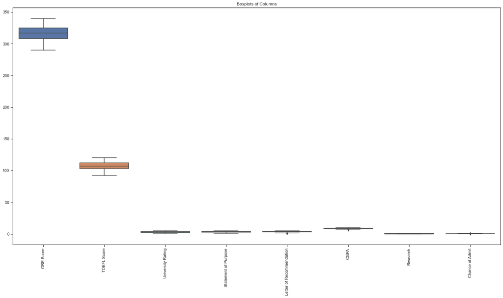

```python
import seaborn as sns
import matplotlib.pyplot as plt

# Plot boxplots for each column
sns.set(style="ticks")
plt.figure(figsize=(24, 12))
sns.boxplot(data=addmision_df)
plt.title("Boxplots of Columns")
plt.xticks(rotation=90)  # Rotate x-axis labels for better readability
plt.show()
```

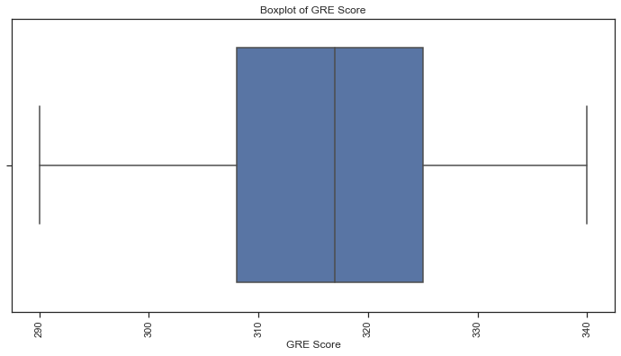

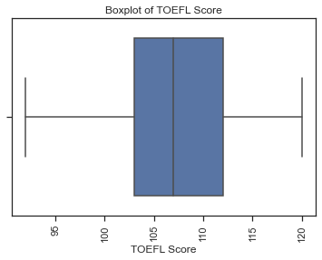

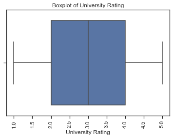

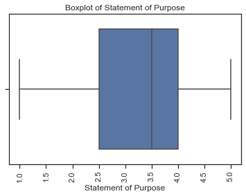

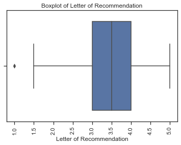

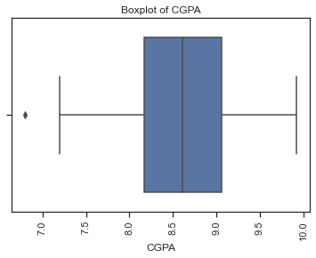

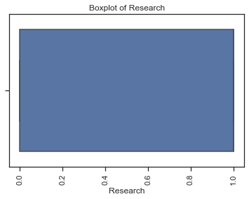

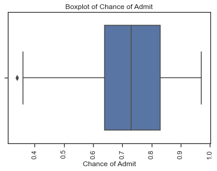

```python
import seaborn as sns
import matplotlib.pyplot as plt

# Plot boxplots for each column
sns.set(style="ticks")
plt.figure(figsize=(12, 6))
for column in addmision_df.columns:
    sns.boxplot(x=column, data=addmision_df)
    plt.title(f"Boxplot of {column}")
    plt.xticks(rotation=90)  # Rotate x-axis labels for better readability
    plt.show()
```

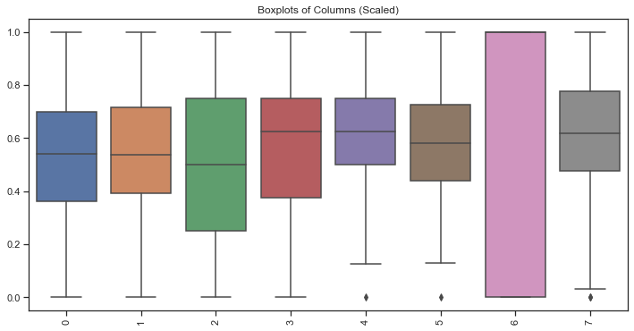

```python
import seaborn as sns
import matplotlib.pyplot as plt
from sklearn.preprocessing import MinMaxScaler

# Create a copy of the dataframe for scaling
scaled_df = addmision_df.copy()

# Scale the numerical columns using Min-Max normalization
scaler = MinMaxScaler()
scaled_df = scaler.fit_transform(scaled_df)

# Plot boxplots for each column
sns.set(style="ticks")
plt.figure(figsize=(12, 6))
sns.boxplot(data=scaled_df)
plt.title("Boxplots of Columns (Scaled)")
plt.xticks(rotation=90)  # Rotate x-axis labels for better readability
plt.show()
```

```python
addmision_df
```

|  | GRE Score | TOEFL Score | University Rating | Statement of Purpose | Letter of Recommendation | CGPA | Research | Chance of Admit |
| --- | --- | --- | --- | --- | --- | --- | --- | --- |
| 0 | 337 | 118 | 4 | 4.5 | 4.5 | 9.65 | 1 | 0.92 |
| 1 | 324 | 107 | 4 | 4.0 | 4.5 | 8.87 | 1 | 0.76 |
| 2 | 316 | 104 | 3 | 3.0 | 3.5 | 8.00 | 1 | 0.72 |
| 3 | 322 | 110 | 3 | 3.5 | 2.5 | 8.67 | 1 | 0.80 |
| 4 | 314 | 103 | 2 | 2.0 | 3.0 | 8.21 | 0 | 0.65 |
| ... | ... | ... | ... | ... | ... | ... | ... | ... |
| 395 | 324 | 110 | 3 | 3.5 | 3.5 | 9.04 | 1 | 0.82 |
| 396 | 325 | 107 | 3 | 3.0 | 3.5 | 9.11 | 1 | 0.84 |
| 397 | 330 | 116 | 4 | 5.0 | 4.5 | 9.45 | 1 | 0.91 |
| 398 | 312 | 103 | 3 | 3.5 | 4.0 | 8.78 | 0 | 0.67 |
| 399 | 333 | 117 | 4 | 5.0 | 4.0 | 9.66 | 1 | 0.95 |

400 rows × 8 columns

### 14. Data Splitting:

Split the dataset into training and testing subsets. The training set is used to train the machine learning model, while the testing set is used to evaluate its performance.

```python
from sklearn.model_selection import train_test_split

# Separate the features (X) and the target variable (y)
X = addmision_df.drop('Chance of Admit', axis=1)
y = addmision_df['Chance of Admit']

# Split the data into training and testing sets
X_train, X_test, y_train, y_test = train_test_split(X, y, test_size=0.2, random_state=42)
```

## 15. Model Training and Evaluation:

### 16. Linear Regression:

```python
from sklearn.linear_model import LinearRegression
from sklearn.model_selection import cross_val_score
from sklearn.metrics import mean_squared_error, mean_absolute_error, r2_score

# Create a Linear Regression model
model = LinearRegression()

# Train the model on the training set
model.fit(X_train, y_train)

# Predict on the training set
y_train_pred = model.predict(X_train)

# Evaluate on the training set
train_mse = mean_squared_error(y_train, y_train_pred)
train_rmse = train_mse ** 0.5
train_mae = mean_absolute_error(y_train, y_train_pred)
train_r2 = r2_score(y_train, y_train_pred)

print("Training Set Evaluation:")
print("MSE:", train_mse)
print("RMSE:", train_rmse)
print("MAE:", train_mae)
print("R-squared:", train_r2)
print()

# Perform cross-validation on the training set
cv_scores = cross_val_score(model, X_train, y_train, cv=5, scoring='neg_mean_squared_error')
cv_rmse_scores = (-cv_scores) ** 0.5
cv_mae_scores = -cross_val_score(model, X_train, y_train, cv=5, scoring='neg_mean_absolute_error')
cv_r2_scores = cross_val_score(model, X_train, y_train, cv=5, scoring='r2')

print("Cross-Validation Evaluation:")
print("Average RMSE:", cv_rmse_scores.mean())
print("Average MAE:", cv_mae_scores.mean())
print("Average R-squared:", cv_r2_scores.mean())
print()

# Predict on the test set
y_test_pred = model.predict(X_test)

# Evaluate on the test set
test_mse = mean_squared_error(y_test, y_test_pred)
test_rmse = test_mse ** 0.5
test_mae = mean_absolute_error(y_test, y_test_pred)
test_r2 = r2_score(y_test, y_test_pred)

print("Test Set Evaluation:")
print("MSE:", test_mse)
print("RMSE:", test_rmse)
print("MAE:", test_mae)
print("R-squared:", test_r2)
print()

# Evaluate the model on the test set again
best_model_index = cv_rmse_scores.argmin()

print("Best Model Evaluation:")
print("RMSE:", cv_rmse_scores[best_model_index])
print("MAE:", cv_mae_scores[best_model_index])
print("R-squared:", cv_r2_scores[best_model_index])
print()
```

```
Training Set Evaluation:
MSE: 0.0038704218434173236
RMSE: 0.062212714483595104
MAE: 0.04388752247366184
R-squared: 0.7951946003191085

Cross-Validation Evaluation:
Average RMSE: 0.0633597676198648
Average MAE: 0.045139212510461754
Average R-squared: 0.7806642370301871

Test Set Evaluation:
MSE: 0.004617003377285012
RMSE: 0.06794853476922819
MAE: 0.04795673362091195
R-squared: 0.8212082591486991

Best Model Evaluation:
RMSE: 0.05205197582449284
MAE: 0.03710036359000078
R-squared: 0.8736688591119411
```

### 17. Decision Tree regression

```python
from sklearn.tree import DecisionTreeRegressor
from sklearn.model_selection import GridSearchCV
from sklearn.metrics import mean_squared_error, mean_absolute_error, r2_score

# Create a Decision Tree model
model = DecisionTreeRegressor()

# Define the hyperparameter grid for optimization
param_grid = {
    'max_depth': [None, 5, 10, 15],
    'min_samples_split': [2, 5, 10],
    'min_samples_leaf': [1, 2, 4]
}

# Perform grid search to find the best parameters
grid_search = GridSearchCV(model, param_grid, scoring='neg_mean_squared_error', cv=5)
grid_search.fit(X_train, y_train)

# Get the best model with optimized parameters
best_model = grid_search.best_estimator_

# Train the best model on the full training set
best_model.fit(X_train, y_train)

# Predict on the training set
y_train_pred = best_model.predict(X_train)

# Evaluate on the training set
train_mse = mean_squared_error(y_train, y_train_pred)
train_rmse = train_mse ** 0.5
train_mae = mean_absolute_error(y_train, y_train_pred)
train_r2 = r2_score(y_train, y_train_pred)

print("Training Set Evaluation:")
print("MSE:", train_mse)
print("RMSE:", train_rmse)
print("MAE:", train_mae)
print("R-squared:", train_r2)
print()

# Perform cross-validation on the training set with the best model
cv_scores = cross_val_score(best_model, X_train, y_train, cv=5, scoring='neg_mean_squared_error')
cv_rmse_scores = (-cv_scores) ** 0.5
cv_mae_scores = -cross_val_score(best_model, X_train, y_train, cv=5, scoring='neg_mean_absolute_error')
cv_r2_scores = cross_val_score(best_model, X_train, y_train, cv=5, scoring='r2')

print("Cross-Validation Evaluation:")
print("Average RMSE:", cv_rmse_scores.mean())
print("Average MAE:", cv_mae_scores.mean())
print("Average R-squared:", cv_r2_scores.mean())
print()

# Predict on the test set
y_test_pred = best_model.predict(X_test)

# Evaluate on the test set
test_mse = mean_squared_error(y_test, y_test_pred)
test_rmse = test_mse ** 0.5
test_mae = mean_absolute_error(y_test, y_test_pred)
test_r2 = r2_score(y_test, y_test_pred)

print("Test Set Evaluation:")
print("MSE:", test_mse)
print("RMSE:", test_rmse)
print("MAE:", test_mae)
print("R-squared:", test_r2)
```

```
Training Set Evaluation:
MSE: 0.0032704007937490454
RMSE: 0.05718741814200957
MAE: 0.04132891823813567
R-squared: 0.8269450285323181

Cross-Validation Evaluation:
Average RMSE: 0.07493914451222125
Average MAE: 0.05524998402527208
Average R-squared: 0.6926216818946942

Test Set Evaluation:
MSE: 0.005284783142405122
RMSE: 0.07269651396322331
MAE: 0.051391906245636075
R-squared: 0.7953487357837182
```

```python
from sklearn.tree import DecisionTreeRegressor
from sklearn.model_selection import GridSearchCV
from sklearn.metrics import mean_squared_error, mean_absolute_error, r2_score

# Create a Decision Tree regressor
model = DecisionTreeRegressor()

# Define the parameter grid for optimization
param_grid = {
    'max_depth': [3, 5, 7],
    'min_samples_split': [2, 5, 10],
    'min_samples_leaf': [1, 2, 4]
}

# Perform grid search for parameter optimization
grid_search = GridSearchCV(estimator=model, param_grid=param_grid, cv=5, scoring='neg_mean_squared_error')
grid_search.fit(X_train, y_train)

# Get the best model from the grid search
best_model = grid_search.best_estimator_

# Predict on the training set using the best model
y_train_pred = best_model.predict(X_train)

# Evaluate on the training set
train_mse = mean_squared_error(y_train, y_train_pred)
train_rmse = train_mse ** 0.5
train_mae = mean_absolute_error(y_train, y_train_pred)
train_r2 = r2_score(y_train, y_train_pred)

print("Training Set Evaluation:")
print("MSE:", train_mse)
print("RMSE:", train_rmse)
print("MAE:", train_mae)
print("R-squared:", train_r2)
print()

# Perform cross-validation on the training set using the best model
cv_scores = cross_val_score(best_model, X_train, y_train, cv=5, scoring='neg_mean_squared_error')
cv_rmse_scores = (-cv_scores) ** 0.5
cv_mae_scores = -cross_val_score(best_model, X_train, y_train, cv=5, scoring='neg_mean_absolute_error')
cv_r2_scores = cross_val_score(best_model, X_train, y_train, cv=5, scoring='r2')

print("Cross-Validation Evaluation:")
print("Average RMSE:", cv_rmse_scores.mean())
print("Average MAE:", cv_mae_scores.mean())
print("Average R-squared:", cv_r2_scores.mean())
print()

# Predict on the test set using the best model
y_test_pred = best_model.predict(X_test)

# Evaluate on the test set
test_mse = mean_squared_error(y_test, y_test_pred)
test_rmse = test_mse ** 0.5
test_mae = mean_absolute_error(y_test, y_test_pred)
test_r2 = r2_score(y_test, y_test_pred)

print("Best Model Evaluation:")
print("RMSE:", test_rmse)
print("MAE:", test_mae)
print("R-squared:", test_r2)
print()
```

```
Training Set Evaluation:
MSE: 0.0032704007937490454
RMSE: 0.05718741814200957
MAE: 0.04132891823813566
R-squared: 0.8269450285323181

Cross-Validation Evaluation:
Average RMSE: 0.07490752243914053
Average MAE: 0.055294626882414946
Average R-squared: 0.6928024798440648

Best Model Evaluation:
RMSE: 0.0729387179754698
MAE: 0.051516906245636075
R-squared: 0.793982785018453
```

### 18. Gradient Boosting regression:

```python
from sklearn.ensemble import GradientBoostingRegressor
from sklearn.model_selection import GridSearchCV
from sklearn.metrics import mean_squared_error, mean_absolute_error, r2_score
from sklearn.model_selection import cross_val_score

# Create a Gradient Boosting regressor
model = GradientBoostingRegressor()

# Define the parameter grid for optimization
param_grid = {
    'learning_rate': [0.1, 0.05, 0.01],
    'n_estimators': [100, 200, 300],
    'max_depth': [3, 5, 7]
}

# Perform grid search for parameter optimization
grid_search = GridSearchCV(estimator=model, param_grid=param_grid, cv=5, scoring='neg_mean_squared_error')
grid_search.fit(X_train, y_train)

# Get the best model from the grid search
best_model = grid_search.best_estimator_

# Predict on the training set using the best model
y_train_pred = best_model.predict(X_train)

# Evaluate on the training set
train_mse = mean_squared_error(y_train, y_train_pred)
train_rmse = train_mse ** 0.5
train_mae = mean_absolute_error(y_train, y_train_pred)
train_r2 = r2_score(y_train, y_train_pred)

print("Training Set Evaluation:")
print("MSE:", train_mse)
print("RMSE:", train_rmse)
print("MAE:", train_mae)
print("R-squared:", train_r2)
print()

# Perform cross-validation on the training set using the best model
cv_scores = cross_val_score(best_model, X_train, y_train, cv=5, scoring='neg_mean_squared_error')
cv_rmse_scores = (-cv_scores) ** 0.5
cv_mae_scores = -cross_val_score(best_model, X_train, y_train, cv=5, scoring='neg_mean_absolute_error')
cv_r2_scores = cross_val_score(best_model, X_train, y_train, cv=5, scoring='r2')

print("Cross-Validation Evaluation:")
print("Average RMSE:", cv_rmse_scores.mean())
print("Average MAE:", cv_mae_scores.mean())
print("Average R-squared:", cv_r2_scores.mean())
print()

# Predict on the test set using the best model
y_test_pred = best_model.predict(X_test)

# Evaluate on the test set
test_mse = mean_squared_error(y_test, y_test_pred)
test_rmse = test_mse ** 0.5
test_mae = mean_absolute_error(y_test, y_test_pred)
test_r2 = r2_score(y_test, y_test_pred)

print("Best Model Evaluation:")
print("RMSE:", test_rmse)
print("MAE:", test_mae)
print("R-squared:", test_r2)
print()
```

```
Training Set Evaluation:
MSE: 0.0020989912113151244
RMSE: 0.045814748840467566
MAE: 0.033388776776432684
R-squared: 0.8889307803253526

Cross-Validation Evaluation:
Average RMSE: 0.06762271702424758
Average MAE: 0.049179892709014954
Average R-squared: 0.752806727603207

Best Model Evaluation:
RMSE: 0.06995741736457572
MAE: 0.04753249651618032
R-squared: 0.8104801093749469
```

### 19. Support Vector Machines (SVM) regression:

```python
from sklearn.svm import SVR
from sklearn.model_selection import GridSearchCV
from sklearn.metrics import mean_squared_error, mean_absolute_error, r2_score
from sklearn.model_selection import cross_val_score

# Create an SVR (Support Vector Regression) model
model = SVR()

# Define the parameter grid for optimization
param_grid = {
    'kernel': ['linear', 'rbf'],
    'C': [0.1, 1, 10],
    'epsilon': [0.01, 0.1, 1]
}

# Perform grid search for parameter optimization
grid_search = GridSearchCV(estimator=model, param_grid=param_grid, cv=5, scoring='neg_mean_squared_error')
grid_search.fit(X_train, y_train)

# Get the best model from the grid search
best_model = grid_search.best_estimator_

# Predict on the training set using the best model
y_train_pred = best_model.predict(X_train)

# Evaluate on the training set
train_mse = mean_squared_error(y_train, y_train_pred)
train_rmse = train_mse ** 0.5
train_mae = mean_absolute_error(y_train, y_train_pred)
train_r2 = r2_score(y_train, y_train_pred)

print("Training Set Evaluation:")
print("MSE:", train_mse)
print("RMSE:", train_rmse)
print("MAE:", train_mae)
print("R-squared:", train_r2)
print()

# Perform cross-validation on the training set using the best model
cv_scores = cross_val_score(best_model, X_train, y_train, cv=5, scoring='neg_mean_squared_error')
cv_rmse_scores = (-cv_scores) ** 0.5
cv_mae_scores = -cross_val_score(best_model, X_train, y_train, cv=5, scoring='neg_mean_absolute_error')
cv_r2_scores = cross_val_score(best_model, X_train, y_train, cv=5, scoring='r2')

print("Cross-Validation Evaluation:")
print("Average RMSE:", cv_rmse_scores.mean())
print("Average MAE:", cv_mae_scores.mean())
print("Average R-squared:", cv_r2_scores.mean())
print()

# Predict on the test set using the best model
y_test_pred = best_model.predict(X_test)

# Evaluate on the test set
test_mse = mean_squared_error(y_test, y_test_pred)
test_rmse = test_mse ** 0.5
test_mae = mean_absolute_error(y_test, y_test_pred)
test_r2 = r2_score(y_test, y_test_pred)

print("Best Model Evaluation:")
print("RMSE:", test_rmse)
print("MAE:", test_mae)
print("R-squared:", test_r2)
print()
```

```
Training Set Evaluation:
MSE: 0.004023125252375621
RMSE: 0.06342811090025953
MAE: 0.04284089148167288
R-squared: 0.7871142194279327

Cross-Validation Evaluation:
Average RMSE: 0.06374393425446351
Average MAE: 0.04412335490836301
Average R-squared: 0.7772133138126497

Best Model Evaluation:
RMSE: 0.07199279586582076
MAE: 0.048889409956293775
R-squared: 0.7992916962773076
```

### 20. deep learning model using Neural Networks for regression

```python
import tensorflow as tf
from tensorflow.keras.models import Sequential
from tensorflow.keras.layers import Dense
from tensorflow.keras.callbacks import EarlyStopping
from sklearn.metrics import mean_squared_error, mean_absolute_error, r2_score

# Get the number of features in the input data
input_dim = X_train.shape[1]

# Define the model architecture
model = Sequential()
model.add(Dense(64, activation='relu', input_shape=(input_dim,)))
model.add(Dense(32, activation='relu'))
model.add(Dense(1))

# Compile the model
model.compile(optimizer='adam', loss='mean_squared_error')

# Set up early stopping
early_stopping = EarlyStopping(patience=5, restore_best_weights=True)

# Train the model
history = model.fit(X_train, y_train, epochs=100, batch_size=32, validation_split=0.2, callbacks=[early_stopping])

# Predict on the training set
y_train_pred = model.predict(X_train)

# Evaluate on the training set
train_mse = mean_squared_error(y_train, y_train_pred)
train_rmse = train_mse ** 0.5
train_mae = mean_absolute_error(y_train, y_train_pred)
train_r2 = r2_score(y_train, y_train_pred)

print("Training Set Evaluation:")
print("MSE:", train_mse)
print("RMSE:", train_rmse)
print("MAE:", train_mae)
print("R-squared:", train_r2)
print()

# Predict on the test set
y_test_pred = model.predict(X_test)

# Evaluate on the test set
test_mse = mean_squared_error(y_test, y_test_pred)
test_rmse = test_mse ** 0.5
test_mae = mean_absolute_error(y_test, y_test_pred)
test_r2 = r2_score(y_test, y_test_pred)

print("Test Set Evaluation:")
print("MSE:", test_mse)
print("RMSE:", test_rmse)
print("MAE:", test_mae)
print("R-squared:", test_r2)
print()
```

```
Training Set Evaluation:
MSE: 0.1403363003104333
RMSE: 0.37461486931304966
MAE: 0.29328347675851546
R-squared: -6.425968857554547

Test Set Evaluation:
MSE: 0.11031408056549567
RMSE: 0.3321356357958231
MAE: 0.26757602379098533
R-squared: -3.271871794972287
```

### 21. Ridge Regression model:

```python
from sklearn.linear_model import Ridge
from sklearn.metrics import mean_squared_error, mean_absolute_error, r2_score

# Create a Ridge Regression model
ridge_model = Ridge(alpha=0.5)

# Train the model
ridge_model.fit(X_train, y_train)

# Predict on the training set
y_train_pred = ridge_model.predict(X_train)

# Evaluate on the training set
train_mse = mean_squared_error(y_train, y_train_pred)
train_rmse = train_mse ** 0.5
train_mae = mean_absolute_error(y_train, y_train_pred)
train_r2 = r2_score(y_train, y_train_pred)

print("Training Set Evaluation:")
print("MSE:", train_mse)
print("RMSE:", train_rmse)
print("MAE:", train_mae)
print("R-squared:", train_r2)
print()

# Predict on the test set
y_test_pred = ridge_model.predict(X_test)

# Evaluate on the test set
test_mse = mean_squared_error(y_test, y_test_pred)
test_rmse = test_mse ** 0.5
test_mae = mean_absolute_error(y_test, y_test_pred)
test_r2 = r2_score(y_test, y_test_pred)

print("Test Set Evaluation:")
print("MSE:", test_mse)
print("RMSE:", test_rmse)
print("MAE:", test_mae)
print("R-squared:", test_r2)
print()
```

```
Training Set Evaluation:
MSE: 0.0038708797448345203
RMSE: 0.06221639450204842
MAE: 0.043865529852552175
R-squared: 0.7951703702257085

Test Set Evaluation:
MSE: 0.004626635645277879
RMSE: 0.06801937698389982
MAE: 0.04799484992020026
R-squared: 0.820835253148473
```

### 22. Lasso Regression model:

```python
from sklearn.linear_model import Lasso
from sklearn.metrics import mean_squared_error, mean_absolute_error, r2_score

# Create a Lasso Regression model
lasso_model = Lasso(alpha=0.5)

# Train the model
lasso_model.fit(X_train, y_train)

# Predict on the training set
y_train_pred = lasso_model.predict(X_train)

# Evaluate on the training set
train_mse = mean_squared_error(y_train, y_train_pred)
train_rmse = train_mse ** 0.5
train_mae = mean_absolute_error(y_train, y_train_pred)
train_r2 = r2_score(y_train, y_train_pred)

print("Training Set Evaluation:")
print("MSE:", train_mse)
print("RMSE:", train_rmse)
print("MAE:", train_mae)
print("R-squared:", train_r2)
print()

# Predict on the test set
y_test_pred = lasso_model.predict(X_test)

# Evaluate on the test set
test_mse = mean_squared_error(y_test, y_test_pred)
test_rmse = test_mse ** 0.5
test_mae = mean_absolute_error(y_test, y_test_pred)
test_r2 = r2_score(y_test, y_test_pred)

print("Test Set Evaluation:")
print("MSE:", test_mse)
print("RMSE:", test_rmse)
print("MAE:", test_mae)
print("R-squared:", test_r2)
print()
```

```
Training Set Evaluation:
MSE: 0.008668624436973582
RMSE: 0.09310544794464813
MAE: 0.0735230832425757
R-squared: 0.5412951961509254

Test Set Evaluation:
MSE: 0.012530589022249622
RMSE: 0.1119401135529602
MAE: 0.08717982144101719
R-squared: 0.5147575944599725
```

### 23. XGBoost (Extreme Gradient Boosting):

```python
import xgboost as xgb
from sklearn.model_selection import GridSearchCV
from sklearn.metrics import mean_squared_error, mean_absolute_error, r2_score

# Define the XGBoost model
xgb_model = xgb.XGBRegressor()

# Define the parameter grid for grid search
param_grid = {
    'max_depth': [3, 4, 5],
    'learning_rate': [0.1, 0.01, 0.001],
    'n_estimators': [100, 200, 300],
}

# Create the GridSearchCV object
grid_search = GridSearchCV(estimator=xgb_model, param_grid=param_grid, cv=5, scoring='neg_mean_squared_error')

# Fit the GridSearchCV object to the training data
grid_search.fit(X_train, y_train)

# Get the best model from the grid search
best_xgb_model = grid_search.best_estimator_

# Print the validation test scores for the best model
cv_results = grid_search.cv_results_
best_index = grid_search.best_index_

print("Validation Test Scores for the Best Model:")
print("RMSE:", (-cv_results['mean_test_score'][best_index]) ** 0.5)
print("MAE:", -cv_results['mean_test_score'][best_index])
print("R-squared:", cv_results['mean_test_score'][best_index])
print()

# Predict on the training set
y_train_pred = best_xgb_model.predict(X_train)

# Evaluate on the training set
train_mse = mean_squared_error(y_train, y_train_pred)
train_rmse = train_mse ** 0.5
train_mae = mean_absolute_error(y_train, y_train_pred)
train_r2 = r2_score(y_train, y_train_pred)

print("Training Set Evaluation:")
print("MSE:", train_mse)
print("RMSE:", train_rmse)
print("MAE:", train_mae)
print("R-squared:", train_r2)
print()

# Predict on the test set
y_test_pred = best_xgb_model.predict(X_test)

# Evaluate on the test set
test_mse = mean_squared_error(y_test, y_test_pred)
test_rmse = test_mse ** 0.5
test_mae = mean_absolute_error(y_test, y_test_pred)
test_r2 = r2_score(y_test, y_test_pred)

print("Test Set Evaluation:")
print("MSE:", test_mse)
print("RMSE:", test_rmse)
print("MAE:", test_mae)
print("R-squared:", test_r2)
print()
```

```
Validation Test Scores for the Best Model:
RMSE: 0.06934561919893623
MAE: 0.004808814902083873
R-squared: -0.004808814902083873

Training Set Evaluation:
MSE: 0.002241514368508764
RMSE: 0.0473446339991003
MAE: 0.03700164627283812
R-squared: 0.8813890927900596

Test Set Evaluation:
MSE: 0.004736470237580361
RMSE: 0.06882201855206196
MAE: 0.050137299284338945
R-squared: 0.8165819493583855
```

### 24. Polynomial Regression :

```python
from sklearn.preprocessing import PolynomialFeatures
from sklearn.linear_model import LinearRegression
from sklearn.metrics import mean_squared_error, mean_absolute_error, r2_score
from sklearn.model_selection import train_test_split

# Split the data into training and test sets
X_train, X_test, y_train, y_test = train_test_split(X, y, test_size=0.2, random_state=42)

# Create polynomial features
degree = 2  # Set the degree of the polynomial
poly_features = PolynomialFeatures(degree=degree)
X_train_poly = poly_features.fit_transform(X_train)
X_test_poly = poly_features.transform(X_test)

# Train the Polynomial Regression model
poly_regression = LinearRegression()
poly_regression.fit(X_train_poly, y_train)

# Predict on the training set
y_train_pred = poly_regression.predict(X_train_poly)

# Evaluate on the training set
train_mse = mean_squared_error(y_train, y_train_pred)
train_rmse = train_mse ** 0.5
train_mae = mean_absolute_error(y_train, y_train_pred)
train_r2 = r2_score(y_train, y_train_pred)

print("Training Set Evaluation:")
print("MSE:", train_mse)
print("RMSE:", train_rmse)
print("MAE:", train_mae)
print("R-squared:", train_r2)
print()

# Predict on the test set
y_test_pred = poly_regression.predict(X_test_poly)

# Evaluate on the test set
test_mse = mean_squared_error(y_test, y_test_pred)
test_rmse = test_mse ** 0.5
test_mae = mean_absolute_error(y_test, y_test_pred)
test_r2 = r2_score(y_test, y_test_pred)

print("Test Set Evaluation:")
print("MSE:", test_mse)
print("RMSE:", test_rmse)
print("MAE:", test_mae)
print("R-squared:", test_r2)
print()
```

[output not shown]

*We have now completed the Admission Prediction project, during which we explored various machine learning models.*

## 📞 Contact Me

Connect with me on these platforms to stay updated with my latest projects and articles. I look forward to connecting with you!